# Fairness Evaluation of Clustering Models

### 9.0.2 Diabetes Dataset

- Source: https://archive.ics.uci.edu/ml/datasets/diabetes+130-us+hospitals+for+years+1999-2008
- This dataset was collected from a database of 130 US hospitals spanning a 10 year period from 1999-2008.
- From this dataset of ~100k datapoints, I extracted (age, time-in-hospital, gender) as my attributes with gender being my protected attribute. Note, Unknown/Invalid is a category for the gender. Calling dropna wont get rid of it.
- While preprocessing for this dataset is included, it wont be used in our experiments because attempting to cluster this dataset always resulted in one giant cluster.

```python
df = pd.read_csv("Datasets/diabetic_data.csv")
df = df.dropna()
df = df.sample(frac=1, random_state=0)
attributes = (df[["age", "time_in_hospital"]].values)
protected = (df[["gender"]].values)
indicies = np.tile(protected!= "Unknown/Invalid", (1,2))
attributes= attributes[indicies].reshape((-1,2))
protected = protected[protected != "Unknown/Invalid"]
protected = np.where(protected == "Male", 1, 0)
age_dict = {}
next_age_idx = 1
for d in attributes:        # since the age of the patients is represented as a string containing the possible age range of the patient, it needs to be converted to a numerical value
    if(not age_dict.get(d[0])):
        age_dict[d[0]] = next_age_idx
        next_age_idx += 1
    d[0] = age_dict[d[0]]
attributes = attributes.astype(float)
diabetes_dataset = np.concatenate((protected.reshape(-1,1), attributes), axis=1).astype(float)
diabetes_dataset /= np.linalg.norm(diabetes_dataset, axis=0)
diabetes_protected = protected
print(diabetes_dataset.shape)
```

```
## (101763, 3)
```

### 9.0.3 Bank Dataset

```python
df = pd.read_csv("Datasets/bank-full.csv", delimiter=";")    # preprocessing data
df = df.dropna()
df = df.sample(frac=1, random_state=0)
attributes = df[["age", "balance", "duration"]].values  # extracting attributes used in the paper
protected = df[["marital"]].values    # extracting marital status, which is the protected attribute
ind = protected != "divorced"       # removing divorced people from attributes
indicies = np.tile(protected != "divorced", (1,3))
attributes = attributes[indicies]
protected = protected[protected != "divorced"]
attributes = np.reshape(attributes, (-1, 3))
protected = np.where(protected == "married", 1, 0)    # convering married/single to 1/0
bank_dataset = np.concatenate((protected.reshape(-1,1), attributes), axis=1).astype(float)
bank_dataset /= np.linalg.norm(bank_dataset, axis=0)
bank_protected = protected
bank_df = {'age': bank_dataset[:10,1], 'balance': bank_dataset[:10,2], 'duration': bank_dataset[:10,3], 'marital': bank_dataset[:10,0]}
bank_df = df = pd.DataFrame(data=bank_df)
bank_df
```

```
##         age   balance  duration   marital
## 0  0.004441  0.002089  0.001251  0.006062
## 1  0.004321 -0.000377  0.014752  0.000000
## 2  0.005641 -0.000604  0.003341  0.006062
## 3  0.006842  0.000746  0.001444  0.006062
## 4  0.003961 -0.000604  0.004564  0.006062
## 5  0.003601  0.002684  0.002777  0.000000
## 6  0.003361  0.000642  0.000935  0.000000
## 7  0.005761  0.001309  0.001870  0.006062
## 8  0.007082 -0.000134  0.000564  0.006062
## 9  0.007082  0.000000  0.003520  0.006062
```

# 10 Data Analytics Methods

One of the goals for the clustering team is to implement several of the fairness notions and one of the bias mitigation algorithms as a demonstration of the use cases of the ontology. In order to tackle this goal, we implemented a few of the fairness notions we collected, (Balance, Entropy, Max Fairness Cost, Jung Et Al Individual Fairness Distance, Essential Fairness Maximum Proportion Difference, Per Point Fairness Violations, Aggregate Fairness Violations). Used the notions to evaluate the fairness of our bias mitigation technique , Fairlet Decomposition, by comparing the scores to baseline models (SciKit Learns implementation of K-Means and K-Medians Clustering).

Originally, the bias mitigation algorithm we wanted to implement was the fairlet decomposition algorithm proposed in *Fair Clustering Through Fairlets*. However, that paper lacked any official public repositories. We found another paper, *Scalable Fair Clustering*, that proposed a modification to the fairlet decomposition algorithm that claims to achieve similar results with a better time complexity. Since this paper did infact provide publically available code, we decided to go with this algorithm. The general idea of the fairlet decomposition algorithm is to seperate the dataset into very small (3-5 point clusters) which satisfy the balance notion. These tiny clusters are called fairlets. Afterwards, applying any general clustering algorithm on the fairlets should yield clusters which also satisfy the balance notion, and therefore be deemed fair. This is the general idea of the fairlet algorithm.

The repository for, *Scalable Fair Clustering*, could be found here: https://github.com/talwagner/fair_clustering

The following code chunk contains the code for fairlet decomposition which is copied directly from the official repo.

```python
EPSILON = 0.0001

FAIRLETS = []
FAIRLET_CENTERS = []

class TreeNode:

    def __init__(self):
        self.children = []

    def set_cluster(self, cluster):
        self.cluster = cluster

    def add_child(self, child):
        self.children.append(child)

    def populate_colors(self, colors):
        "Populate auxiliary lists of red and blue points for each node, bottom-up"
        self.reds = []
        self.blues = []
        if len(self.children) == 0:
            # Leaf
            for i in self.cluster:
                if colors[i] == 0:
                    self.reds.append(i)
                else:
                    self.blues.append(i)
        else:
            # Not a leaf
            for child in self.children:
                child.populate_colors(colors)
                self.reds.extend(child.reds)
                self.blues.extend(child.blues)


### K-MEDIAN CODE ###

def kmedian_cost(points, centroids, dataset):
    "Computes and returns k-median cost for given dataset and centroids"
    return sum(np.amin(np.concatenate([np.linalg.norm(dataset[:,:]-dataset[centroid,:], axis=1).reshape((dataset.shape[0], 1)) for centroid in centroids], axis=1), axis=1))

def fair_kmedian_cost(centroids, dataset):
    "Return the fair k-median cost for given centroids and fairlet decomposition"
    total_cost = 0
    for i in range(len(FAIRLETS)):
        # Choose index of centroid which is closest to the i-th fairlet center
        cost_list = [np.linalg.norm(dataset[centroids[j],:]-dataset[FAIRLET_CENTERS[i],:]) for j in range(len(centroids))]
        cost, j = min((cost, j) for (j, cost) in enumerate(cost_list))
        # Assign all points in i-th fairlet to above centroid and compute cost
        total_cost += sum([np.linalg.norm(dataset[centroids[j],:]-dataset[point,:]) for point in FAIRLETS[i]])
    return total_cost


### FAIRLET DECOMPOSITION CODE ###

def balanced(p, q, r, b):
    if r==0 and b==0:
        return True
    if r==0 or b==0:
        return False
    return min(r*1./b, b*1./r) >= p*1./q


def make_fairlet(points, dataset):
    "Adds fairlet to fairlet decomposition, returns median cost"
    FAIRLETS.append(points)
    cost_list = [sum([np.linalg.norm(dataset[center,:]-dataset[point,:]) for point in points]) for center in points]
    cost, center = min((cost, center) for (center, cost) in enumerate(cost_list))
    FAIRLET_CENTERS.append(points[center])
    return cost


def basic_fairlet_decomposition(p, q, blues, reds, dataset):
    """
    Computes vanilla (p,q)-fairlet decomposition of given points (Lemma 3 in NIPS17 paper).
    Returns cost.
    Input: Balance parameters p,q which are non-negative integers satisfying p<=q and gcd(p,q)=1.
    "blues" and "reds" are sets of points indices with balance at least p/q.
    """
    assert p <= q, "Please use balance parameters in the correct order"
    if len(reds) < len(blues):
        temp = blues
        blues = reds
        reds = temp
    R = len(reds)
    B = len(blues)
    assert balanced(p, q, R, B), "Input sets are unbalanced: "+str(R)+","+str(B)

    if R==0 and B==0:
        return 0

    b0 = 0
    r0 = 0
    cost = 0
    while (R-r0)-(B-b0) >= q-p and R-r0 >= q and B-b0 >= p:
        cost += make_fairlet(reds[r0:r0+q]+blues[b0:b0+p], dataset)
        r0 += q
        b0 += p
    if R-r0 + B-b0 >=1 and R-r0 + B-b0 <= p+q:
        cost += make_fairlet(reds[r0:]+blues[b0:], dataset)
        r0 = R
        b0 = B
    elif R-r0 != B-b0 and B-b0 >= p:
        cost += make_fairlet(reds[r0:r0+(R-r0)-(B-b0)+p]+blues[b0:b0+p], dataset)
        r0 += (R-r0)-(B-b0)+p
        b0 += p
    assert R-r0 == B-b0, "Error in computing fairlet decomposition"
    for i in range(R-r0):
        cost += make_fairlet([reds[r0+i], blues[b0+i]], dataset)
    return cost


def node_fairlet_decomposition(p, q, node, dataset, donelist, depth):

    # Leaf
    if len(node.children) == 0:
        node.reds = [i for i in node.reds if donelist[i]==0]
        node.blues = [i for i in node.blues if donelist[i]==0]
        assert balanced(p, q, len(node.reds), len(node.blues)), "Reached unbalanced leaf"
        return basic_fairlet_decomposition(p, q, node.blues, node.reds, dataset)

    # Preprocess children nodes to get rid of points that have already been clustered
    for child in node.children:
        child.reds = [i for i in child.reds if donelist[i]==0]
        child.blues = [i for i in child.blues if donelist[i]==0]

    R = [len(child.reds) for child in node.children]
    B = [len(child.blues) for child in node.children]

    if sum(R) == 0 or sum(B) == 0:
        assert sum(R)==0 and sum(B)==0, "One color class became empty for this node while the other did not"
        return 0

    NR = 0
    NB = 0

    # Phase 1: Add must-remove nodes
    for i in range(len(node.children)):
        if R[i] >= B[i]:
            must_remove_red = max(0, R[i] - int(np.floor(B[i]*q*1./p)))
            R[i] -= must_remove_red
            NR += must_remove_red
        else:
            must_remove_blue = max(0, B[i] - int(np.floor(R[i]*q*1./p)))
            B[i] -= must_remove_blue
            NB += must_remove_blue

    # Calculate how many points need to be added to smaller class until balance
    if NR >= NB:
        # Number of missing blues in (NR,NB)
        missing = max(0, int(np.ceil(NR*p*1./q)) - NB)
    else:
        # Number of missing reds in (NR,NB)
        missing = max(0, int(np.ceil(NB*p*1./q)) - NR)

    # Phase 2: Add may-remove nodes until (NR,NB) is balanced or until no more such nodes
    for i in range(len(node.children)):
        if missing == 0:
            assert balanced(p, q, NR, NB), "Something went wrong"
            break
        if NR >= NB:
            may_remove_blue = B[i] - int(np.ceil(R[i]*p*1./q))
            remove_blue = min(may_remove_blue, missing)
            B[i] -= remove_blue
            NB += remove_blue
            missing -= remove_blue
        else:
            may_remove_red = R[i] - int(np.ceil(B[i]*p*1./q))
            remove_red = min(may_remove_red, missing)
            R[i] -= remove_red
            NR += remove_red
            missing -= remove_red

    # Phase 3: Add unsatuated fairlets until (NR,NB) is balanced
    for i in range(len(node.children)):
        if balanced(p, q, NR, NB):
            break
        if R[i] >= B[i]:
            num_saturated_fairlets = int(R[i]/q)
            excess_red = R[i] - q*num_saturated_fairlets
            excess_blue = B[i] - p*num_saturated_fairlets
        else:
            num_saturated_fairlets = int(B[i]/q)
            excess_red = R[i] - p*num_saturated_fairlets
            excess_blue = B[i] - q*num_saturated_fairlets
        R[i] -= excess_red
        NR += excess_red
        B[i] -= excess_blue
        NB += excess_blue

    assert balanced(p, q, NR, NB), "Constructed node sets are unbalanced"

    reds = []
    blues = []
    for i in range(len(node.children)):
        for j in node.children[i].reds[R[i]:]:
            reds.append(j)
            donelist[j] = 1
        for j in node.children[i].blues[B[i]:]:
            blues.append(j)
            donelist[j] = 1

    assert len(reds)==NR and len(blues)==NB, "Something went horribly wrong"

    return basic_fairlet_decomposition(p, q, blues, reds, dataset) + sum([node_fairlet_decomposition(p, q, child, dataset, donelist, depth+1) for child in node.children])


def tree_fairlet_decomposition(p, q, root, dataset, colors):
    "Main fairlet clustering function, returns cost wrt original metric (not tree metric)"
    assert p <= q, "Please use balance parameters in the correct order"
    root.populate_colors(colors)
    assert balanced(p, q, len(root.reds), len(root.blues)), "Dataset is unbalanced"
    root.populate_colors(colors)
    donelist = [0] * dataset.shape[0]
    return node_fairlet_decomposition(p, q, root, dataset, donelist, 0)


### QUADTREE CODE ###

def build_quadtree(dataset, max_levels=0, random_shift=True):
    "If max_levels=0 there no level limit, quadtree will partition until all clusters are singletons"
    dimension = dataset.shape[1]
    lower = np.amin(dataset, axis=0)
    upper = np.amax(dataset, axis=0)

    shift = np.zeros(dimension)
    if random_shift:
        for d in range(dimension):
            spread = upper[d] - lower[d]
            shift[d] = np.random.uniform(0, spread)
            upper[d] += spread

    return build_quadtree_aux(dataset, range(dataset.shape[0]), lower, upper, max_levels, shift)


def build_quadtree_aux(dataset, cluster, lower, upper, max_levels, shift):
    """
    "lower" is the "bottom-left" (in all dimensions) corner of current hypercube
    "upper" is the "upper-right" (in all dimensions) corner of current hypercube
    """

    dimension = dataset.shape[1]
    cell_too_small = True
    for i in range(dimension):
        if upper[i]-lower[i] > EPSILON:
            cell_too_small = False

    node = TreeNode()
    if max_levels==1 or len(cluster)<=1 or cell_too_small:
        # Leaf
        node.set_cluster(cluster)
        return node

    # Non-leaf
    midpoint = 0.5 * (lower + upper)
    subclusters = defaultdict(list)
    for i in cluster:
        subclusters[tuple([dataset[i,d]+shift[d]<=midpoint[d] for d in range(dimension)])].append(i)
    for edge, subcluster in subclusters.items():
        sub_lower = np.zeros(dimension)
        sub_upper = np.zeros(dimension)
        for d in range(dimension):
            if edge[d]:
                sub_lower[d] = lower[d]
                sub_upper[d] = midpoint[d]
            else:
                sub_lower[d] = midpoint[d]
                sub_upper[d] = upper[d]
        node.add_child(build_quadtree_aux(dataset, subcluster, sub_lower, sub_upper, max_levels-1, shift))
    return node
```

# 11 Evaluated Metrics:

The following are a list of notions whose metrics we have implemented and evaluated in our experiments.

#### 11.0.0.1 Disparate Impact:

Balance: This code calculates the balance of a clustering algorithm. The balance is essentially the proportion of the number of label 0 for the protected attributes in a dataset over the number of label 1s. The goal for balance is to have the balance of the entire dataset be equal to the minimum balance for the clusters. For more than two classes of data, it is recommended to use Max Fairness Cost or Essential Fairness.

```python
def balance(protected, clusters, num_clusters):
    a_entire = np.sum(protected==0)
    b_entire = np.sum(protected!=0)
    bal_arr = np.zeros(num_clusters)
    for i in range(num_clusters):
        c = protected[clusters==i]
        a = np.sum(c==0)
        b = np.sum(c!=0)
        bal_arr[i] = min(a/b, b/a)
    return np.min(bal_arr), min(a_entire/b_entire, b_entire/a_entire), bal_arr
```

#### 11.0.0.2 Relaxed Disparate Impact:

Max Fairness Cost: The max fairness cost is the maximum of the difference between the proprotion of protected attributs in a cluster and the ideal proportion. The goal is to minimize the max fairness cost as a high max fairness cost is less fair.

```python
def max_fairness_cost(protected, clusters, num_clusters, ideal_proportion):
    cost_arr = np.zeros(num_clusters)
    for i in range(num_clusters):
        c = protected[clusters==i]
        a = np.sum(c==0)
        b = np.sum(c!=0)
        cost_arr[i] = np.abs(min(a/b, b/a) - ideal_proportion)
    return np.max(cost_arr), cost_arr
```

#### 11.0.0.3 Essential Fairness:

A clustering is fair if the ratio of all protected classes is preserved in each cluster. A relaxed version of this metric allows for the ratio of all protected classes to be preserved within a certain error.

```python
def essential_fairness(protected, clusters, num_clusters):
    '''
    Calculates the difference in proportion for a protected class
    in the original dataset versus the proportion in each cluster.
    Returns the maximum difference.
    '''
    diffs = np.zeros(num_clusters)
    for i in range(num_clusters):
        c = protected[clusters==i]
        cluster_prot = np.sum(c==0)/c.shape[0]
        dataset_prot = np.sum(protected==0)/protected.shape[0]
        diffs[i] = cluster_prot-dataset_prot
    return np.max(diffs), diffs
```

#### 11.0.0.4 Independence (Statistical Parity)

Entropy: Entropy is the measure of how well distributed the protected attribute is in the dataset. The lower the entropy value, the less distributed. The higher the entropy, the more distributed the protected attribute is. Therefore, a higher entropy value is more fair.

```python
def entropy(dataset, protected, clusters, num_clusters):
    e = 0
    for i in range(num_clusters):
        c = protected[clusters==i]
        c_dataset = dataset[clusters==i]
        c_protected = c_dataset[np.tile((c==0).reshape(-1,1), (1,c_dataset.shape[1]))].reshape(-1, c_dataset.shape[1])
        next_e = (np.linalg.norm(c_protected)/c.shape[0]) * np.log(np.linalg.norm(c_protected)/c.shape[0])
        if (not np.isnan(next_e)):
            e += next_e
    return -e
```

#### 11.0.0.5 Load Balance

Jung et al Individual Fairness: A clustering is fair if each point finds a center within its neighborhood radius. This fairness accounts for population density. The goal is to minimize maximum travel distance in k-center, average travel distance in k-median, and the sum of squares of travel distances in k-means.

```python
def jung_fairness(dataset, clusters, num_clusters, centers, method="median"):
    '''
    Evaluates jung et al fairness and returns the maximum average
    travel distance in k-median, sum of squares of travel distances in
    k-means, and the maximum travel distance in k-center.
    Distance calculation is normalized
    '''
    objs = np.zeros(num_clusters)
    for i in range(num_clusters):
        c = dataset[clusters==i]
        dists = np.linalg.norm(c - centers[i], axis=1)
        if method == "median":
            objs[i] = np.mean(dists)
        elif method == "mean":
            objs[i] = np.sum(np.square(dists))
        else:
            objs[i] = np.max(dists)

    return max(objs), objs
```

#### 11.0.0.6 Individual Fairness

Per Point Fairness: For any point, the distance from it to the cluster center must be less than alpha times the distance from the cluster center to the closest point.

Aggregate Fairness: For any point, the distance from it to the cluster center must be less than alpha times the average distance from the cluster center to a point in the cluster.

```python
def pp_agg_fairness(dataset, clusters, num_clusters, centers, alpha = 6, agg=False):
    '''
    Calculates either per point or aggregate fairness metric,
    returns the maximum violations in a cluster and violations
    per cluster.
    Distance calculation is normalized
    '''
    violations = np.zeros(num_clusters)
    for i in range(num_clusters):
        c = dataset[clusters==i]
        dists = np.linalg.norm(c - centers[i], axis=1)
        if agg:
            obj = alpha * np.mean(dists)
        else:
            obj = alpha * np.min(dists)
        diffs = dists - obj
        violations[i] = np.sum(diffs>0)/diffs.shape[0]
    return np.max(violations), violations
```

# 12 Ideal Cluster Size

Our inital number of clusters was selected to be 20 because that is what is used in the *Fair Clustering With Fairlets* paper. However, when running the code on the datasets, it is quicky apparent that 20 clusters is way too high. In order to find the optimal number of clusters, an elbow plot is used. Below is code which will calculate the optimal number of clusters for both sklearn’s k-means and k-medians clustering algorithm using an elbow plot.

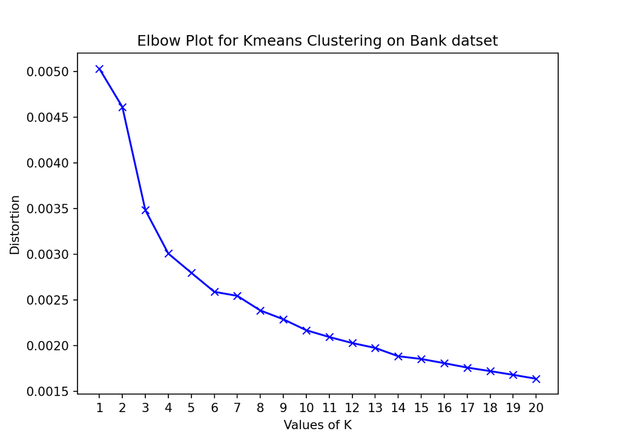

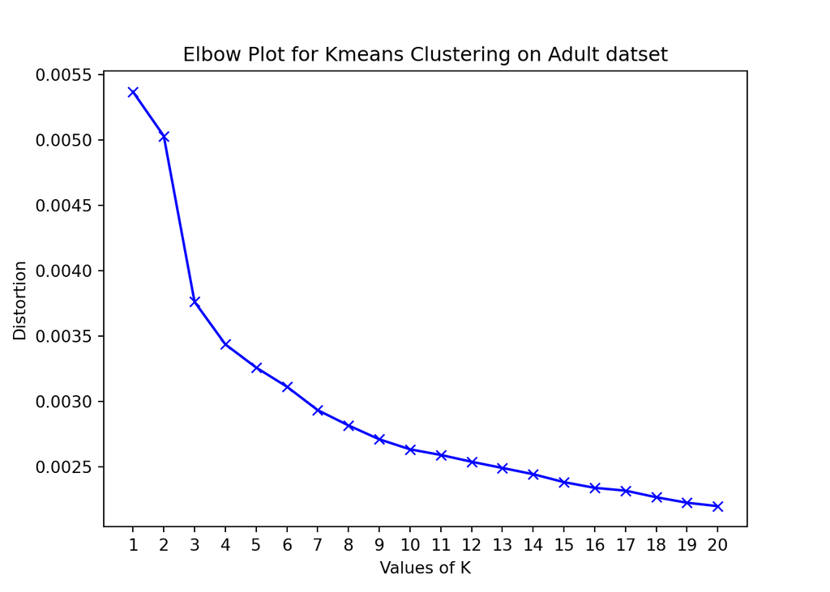

```python
num_points = 10000

datasets = [bank_dataset[:num_points], adult_dataset[:num_points]]
K = range(1,21)
for i, X in enumerate(datasets):
    distortions = []
    inertias = []
    mapping1 = {}
    mapping2 = {}
    for k in K:
        kmeanModel = KMeans(n_clusters=k, random_state=0).fit(X)
        kmeanModel.fit(X)

        distortions.append(sum(np.min(cdist(X, kmeanModel.cluster_centers_,
                                            'euclidean'), axis=1)) / X.shape[0])
        inertias.append(kmeanModel.inertia_)

        mapping1[k] = sum(np.min(cdist(X, kmeanModel.cluster_centers_,
                                    'euclidean'), axis=1)) / X.shape[0]
        mapping2[k] = kmeanModel.inertia_
    plt.plot(K, distortions, 'bx-')
    plt.xlabel('Values of K')
    plt.xticks(K)
    plt.ylabel('Distortion')
    plt.title(f'Elbow Plot for Kmeans Clustering on {"Bank" if i == 0 else "Adult"} datset')
    plt.show()
```

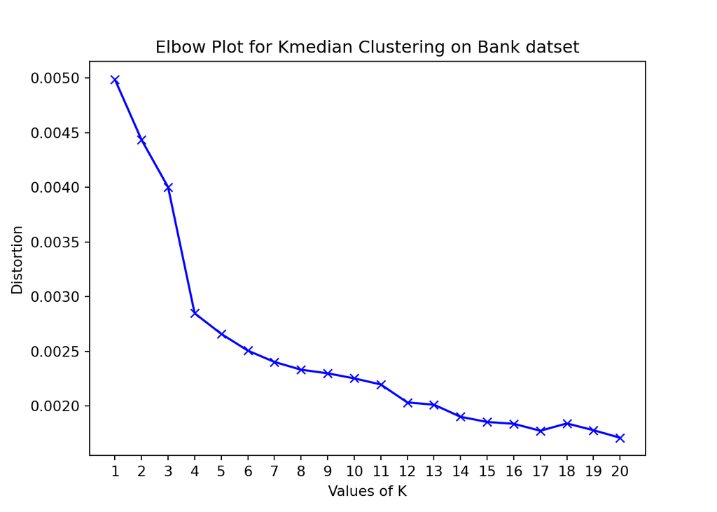

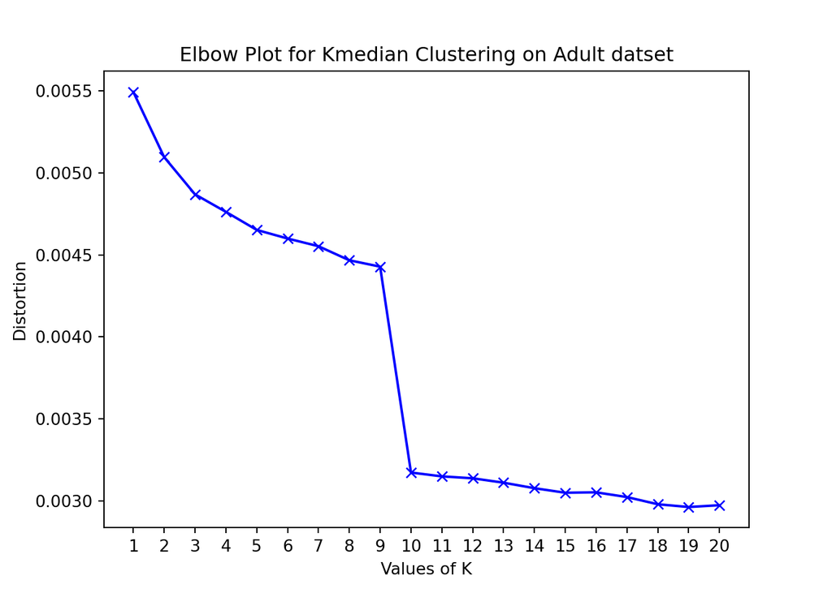

```python
for i, X in enumerate(datasets):
    distortions = []
    inertias = []
    mapping1 = {}
    mapping2 = {}
    for k in K:
        kmedianModel = KMedoids(n_clusters=k, random_state=0).fit(X)
        kmedianModel.fit(X)

        distortions.append(sum(np.min(cdist(X, kmedianModel.cluster_centers_,
                                            'euclidean'), axis=1)) / X.shape[0])
        inertias.append(kmedianModel.inertia_)

        mapping1[k] = sum(np.min(cdist(X, kmedianModel.cluster_centers_,
                                    'euclidean'), axis=1)) / X.shape[0]
        mapping2[k] = kmedianModel.inertia_
    plt.plot(K, distortions, 'bx-')
    plt.xticks(K)
    plt.xlabel('Values of K')
    plt.ylabel('Distortion')
    plt.title(f'Elbow Plot for Kmedian Clustering on {"Bank" if i == 0 else "Adult"} datset')
    plt.show()
```

# 13 Experimental Results

Now that the ideal number of clusters is calculated, we can cluster the datasets using a baseline KMeans and KMedian clustering algorithm, which in this case are the scikit learn KMeans and KMedian clustering algorithm. We will be using 10K points from each of the datasets for our experiment because we wanted to use a fairly large number of points to ensure that our sample is reflective of the entire dataset.

```python
num_points = 10000
bank_mean_model = KMeans(n_clusters=5, random_state=0).fit(bank_dataset[:num_points])
adult_mean_model = KMeans(n_clusters=6, random_state=0).fit(adult_dataset[:num_points])
bank_median_model = KMedoids(n_clusters=4, random_state=0).fit(bank_dataset[:num_points])
adult_median_model = KMedoids(n_clusters=9, random_state=0).fit(adult_dataset[:num_points])
```

Next we will apply the notions onto the Baseline models, which are the KMeans and KMedians clustering algorithm implementaions from SciKit Learn

### 13.0.1 Baseline KMeans on Bank Dataset

```python
bal, bal_dataset, bal_arr = balance(bank_protected[:num_points], bank_mean_model.labels_, 5)
print(f"Minimum Cluster Balance: {bal:.4f}")
```

```
## Minimum Cluster Balance: 0.0000
```

```python
print(f"Balance of Entire Dataset: {bal_dataset:.4f}")
```

```
## Balance of Entire Dataset: 0.4661
```

```python
ent = entropy(bank_dataset[:num_points], bank_protected[:num_points], bank_mean_model.labels_, 5)
print(f"Entropy: {ent:.4f}")
```

```
## Entropy: 0.0181
```

```python
mfc, mfc_arr = max_fairness_cost(bank_protected[:num_points], bank_mean_model.labels_, 5, bal_dataset)
print(f"Max Fairness Cost: {mfc:.4f}")
```

```
## Max Fairness Cost: 0.4661
```

```python
jung, jung_arr = jung_fairness(bank_dataset[:num_points], bank_mean_model.labels_, 5, bank_mean_model.cluster_centers_)
print(f"Jung Et Al Individual Fairness Distance: {jung:.4f}")
```

```
## Jung Et Al Individual Fairness Distance: 0.0111
```

```python
essential, essential_arr = essential_fairness(bank_protected[:num_points], bank_mean_model.labels_, 5)
print(f"Essential Fairness Maximum Proportion Difference: {essential:.4f}")
```

```
## Essential Fairness Maximum Proportion Difference: 0.6821
```

```python
pp, pp_arr = pp_agg_fairness(bank_dataset[:num_points], bank_mean_model.labels_, 5, bank_mean_model.cluster_centers_)
print(f"Per Point Fairness Violations: {pp:.4f}")
```

```
## Per Point Fairness Violations: 0.9851
```

```python
agg, agg_arr = pp_agg_fairness(bank_dataset[:num_points], bank_mean_model.labels_, 5, bank_mean_model.cluster_centers_, agg = True)
print(f"Aggregate Fairness Violations: {agg:.4f}")
```

```
## Aggregate Fairness Violations: 0.0023
```

### 13.0.2 Baseline KMeans on Adult Dataset

```python
bal, bal_dataset, bal_arr = balance(adult_protected[:num_points], adult_mean_model.labels_, 6)
print(f"Minimum Cluster Balance: {bal:.4f}")
```

```
## Minimum Cluster Balance: 0.0000
```

```python
print(f"Balance of Entire Dataset: {bal_dataset:.4f}")
```

```
## Balance of Entire Dataset: 0.5008
```

```python
ent = entropy(adult_dataset[:num_points], adult_protected[:num_points], adult_mean_model.labels_, 6)
print(f"Entropy: {ent:.4f}")
```

```
## Entropy: 0.0348
```

```python
mfc, mfc_arr = max_fairness_cost(adult_protected[:num_points], adult_mean_model.labels_, 6, bal_dataset)
print(f"Max Fairness Cost: {mfc:.4f}")
```

```
## Max Fairness Cost: 0.5008
```

```python
jung, jung_arr = jung_fairness(adult_dataset[:num_points], adult_mean_model.labels_, 6, adult_mean_model.cluster_centers_, "mean")
print(f"Jung Et Al Individual Fairness Distance: {jung:.4f}")
```

```
## Jung Et Al Individual Fairness Distance: 0.0477
```

```python
essential, essential_arr = essential_fairness(adult_protected[:num_points], adult_mean_model.labels_, 6)
print(f"Essential Fairness Maximum Proportion Difference: {essential:.4f}")
```

```
## Essential Fairness Maximum Proportion Difference: 0.6663
```

```python
pp, pp_arr = pp_agg_fairness(adult_dataset[:num_points], adult_mean_model.labels_, 6, adult_mean_model.cluster_centers_)
print(f"Per Point Fairness Violations: {pp:.4f}")
```

```
## Per Point Fairness Violations: 0.7870
```

```python
agg, agg_arr = pp_agg_fairness(adult_dataset[:num_points], adult_mean_model.labels_, 6, adult_mean_model.cluster_centers_, agg = True)
print(f"Aggregate Fairness Violations: {agg:.4f}")
```

```
## Aggregate Fairness Violations: 0.0012
```

### 13.0.3 Baseline KMedian on Bank Dataset

```python
bal, bal_dataset, bal_arr = balance(bank_protected[:num_points], bank_median_model.labels_, 4)
print(f"Minimum Cluster Balance: {bal:.4f}")
```

```
## Minimum Cluster Balance: 0.0000
```

```python
print(f"Balance of Entire Dataset: {bal_dataset:.4f}")
```

```
## Balance of Entire Dataset: 0.4661
```

```python
ent = entropy(bank_dataset[:num_points], bank_protected[:num_points], bank_median_model.labels_, 4)
print(f"Entropy: {ent:.4f}")
```

```
## Entropy: 0.0046
```

```python
mfc, mfc_arr = max_fairness_cost(bank_protected[:num_points], bank_median_model.labels_, 4, bal_dataset)
print(f"Max Fairness Cost: {mfc:.4f}")
```

```
## Max Fairness Cost: 0.4661
```

```python
jung, jung_arr = jung_fairness(bank_dataset[:num_points], bank_median_model.labels_, 4, bank_median_model.cluster_centers_)
print(f"Jung Et Al Individual Fairness Distance: {jung:.4f}")
```

```
## Jung Et Al Individual Fairness Distance: 0.0066
```

```python
essential, essential_arr = essential_fairness(bank_protected[:num_points], bank_median_model.labels_, 4)
print(f"Essential Fairness Maximum Proportion Difference: {essential:.4f}")
```

```
## Essential Fairness Maximum Proportion Difference: 0.6821
```

```python
pp, pp_arr = pp_agg_fairness(bank_dataset[:num_points], bank_median_model.labels_, 4, bank_median_model.cluster_centers_)
print(f"Per Point Fairness Violations: {pp:.4f}")
```

```
## Per Point Fairness Violations: 0.9998
```

```python
agg, agg_arr = pp_agg_fairness(bank_dataset[:num_points], bank_median_model.labels_, 4, bank_median_model.cluster_centers_, agg = True)
print(f"Aggregate Fairness Violations: {agg:.4f}")
```

```
## Aggregate Fairness Violations: 0.0083
```

### 13.0.4 Baseline KMedian on Adult Dataset

```python
bal, bal_dataset, bal_arr = balance(adult_protected[:num_points], adult_median_model.labels_, 9)
print(f"Minimum Cluster Balance: {bal:.4f}")
```

```
## Minimum Cluster Balance: 0.2221
```

```python
print(f"Balance of Entire Dataset: {bal_dataset:.4f}")
```

```
## Balance of Entire Dataset: 0.5008
```

```python
ent = entropy(adult_dataset[:num_points], adult_protected[:num_points], adult_median_model.labels_, 9)
print(f"Entropy: {ent:.4f}")
```

```
## Entropy: 0.0154
```

```python
mfc, mfc_arr = max_fairness_cost(adult_protected[:num_points], adult_median_model.labels_, 9, bal_dataset)
print(f"Max Fairness Cost: {mfc:.4f}")
```

```
## Max Fairness Cost: 0.2788
```

```python
jung, jung_arr = jung_fairness(adult_dataset[:num_points], adult_median_model.labels_, 9, adult_median_model.cluster_centers_)
print(f"Jung Et Al Individual Fairness Distance: {jung:.4f}")
```

```
## Jung Et Al Individual Fairness Distance: 0.0052
```

```python
essential, essential_arr = essential_fairness(adult_protected[:num_points], adult_median_model.labels_, 9)
print(f"Essential Fairness Maximum Proportion Difference: {essential:.4f}")
```

```
## Essential Fairness Maximum Proportion Difference: 0.0894
```

```python
pp, pp_arr = pp_agg_fairness(adult_dataset[:num_points], adult_median_model.labels_, 9, adult_median_model.cluster_centers_)
print(f"Per Point Fairness Violations: {pp:.4f}")
```

```
## Per Point Fairness Violations: 0.9994
```

```python
agg, agg_arr = pp_agg_fairness(adult_dataset[:num_points], adult_median_model.labels_, 9, adult_median_model.cluster_centers_, agg = True)
print(f"Aggregate Fairness Violations: {agg:.4f}")
```

```
## Aggregate Fairness Violations: 0.0183
```

Now we can apply the same notions used on the baseline models onto the Fairlet Decomposition algorithm.

### 13.0.5 Fairlet Decomposition on Bank Dataset

```python
EPSILON = 0.0001

FAIRLETS = []
FAIRLET_CENTERS = []

dataset = bank_dataset[:num_points,1:]
colors = bank_dataset[:num_points,0]

root = build_quadtree(dataset)

cost = tree_fairlet_decomposition(3, 7, root, dataset, colors)    # creating fairlets from dataset

fairlet_center_idx = [dataset[index] for index in FAIRLET_CENTERS]    # finding the centers of each fairlet, which will be used for regular k-medians clustering
fairlet_center_pt = np.array([np.array(xi) for xi in fairlet_center_idx])

kmedoids = KMedoids(n_clusters=4, random_state=0).fit(fairlet_center_pt)   # using sklearns kmedioids function

fairlet_clusters = np.zeros(dataset.shape[0])
for i in range(len(FAIRLET_CENTERS)):
    for j in range(len(FAIRLETS)):
        if(FAIRLET_CENTERS[i] in FAIRLETS[j]):
            for k in range(len(FAIRLETS[j])):
                fairlet_clusters[FAIRLETS[j][k]] = kmedoids.labels_[i]

bal, bal_dataset, bal_arr = balance(bank_protected[:num_points], fairlet_clusters, 4)
print(f"Minimum Cluster Balance: {bal:.4f}")
```

```
## Minimum Cluster Balance: 0.4286
```

```python
print(f"Balance of Entire Dataset: {bal_dataset:.4f}")
```

```
## Balance of Entire Dataset: 0.4661
```

```python
ent = entropy(bank_dataset[:num_points], bank_protected[:num_points], fairlet_clusters, 4)
print(f"Entropy of Clusters: {ent:.4f}")
```

```
## Entropy of Clusters: 0.0038
```

```python
mfc, mfc_arr = max_fairness_cost(bank_protected[:num_points], fairlet_clusters, 4, bal_dataset)
print(f"Max Fairness Cost: {mfc:.4f}")
```

```
## Max Fairness Cost: 0.0577
```

```python
jung, jung_arr = jung_fairness(bank_dataset[:num_points, 1:], fairlet_clusters, 4, kmedoids.cluster_centers_)
print(f"Jung Et Al Individual Fairness Distance: {jung:.4f}")
```

```
## Jung Et Al Individual Fairness Distance: 0.0064
```

```python
essential, essential_arr = essential_fairness(bank_protected[:num_points], fairlet_clusters, 4)
print(f"Essential Fairness Maximum Proportion Difference: {essential:.4f}")
```

```
## Essential Fairness Maximum Proportion Difference: 0.0258
```

```python
pp, pp_arr = pp_agg_fairness(bank_dataset[:num_points, 1:], fairlet_clusters, 4, kmedoids.cluster_centers_)
print(f"Per Point Fairness Violations: {pp:.4f}")
```

```
## Per Point Fairness Violations: 0.9997
```

```python
agg, agg_arr = pp_agg_fairness(bank_dataset[:num_points, 1:], fairlet_clusters, 4, kmedoids.cluster_centers_, agg = True)
print(f"Aggregate Fairness Violations: {agg:.4f}")
```

```
## Aggregate Fairness Violations: 0.0073
```

### 13.0.6 Fairlet Decomposition on Adult Dataset

```python
EPSILON = 0.0001

FAIRLETS = []
FAIRLET_CENTERS = []

dataset = adult_dataset[:num_points,1:]
colors = adult_dataset[:num_points,0]

root = build_quadtree(dataset)

cost = tree_fairlet_decomposition(1, 2, root, dataset, colors)    # creating fairlets from dataset

fairlet_center_idx = [dataset[index] for index in FAIRLET_CENTERS]    # finding the centers of each fairlet, which will be used for regular k-medians clustering
fairlet_center_pt = np.array([np.array(xi) for xi in fairlet_center_idx])

kmedoids = KMedoids(n_clusters=9, random_state=0).fit(fairlet_center_pt)   # using sklearns kmedioids function

fairlet_clusters = np.zeros(dataset.shape[0])
for i in range(len(FAIRLET_CENTERS)):
    for j in range(len(FAIRLETS)):
        if(FAIRLET_CENTERS[i] in FAIRLETS[j]):
            for k in range(len(FAIRLETS[j])):
                fairlet_clusters[FAIRLETS[j][k]] = kmedoids.labels_[i]

bal, bal_dataset, bal_arr = balance(adult_protected[:num_points], fairlet_clusters, 9)
print(f"Minimum Cluster Balance: {bal:.4f}")
```

```
## Minimum Cluster Balance: 0.5000
```

```python
print(f"Balance of Entire Dataset: {bal_dataset:.4f}")
```

```
## Balance of Entire Dataset: 0.5008
```

```python
ent = entropy(adult_dataset[:num_points], adult_protected[:num_points], fairlet_clusters, 9)
print(f"Entropy of Clusters: {ent:.4f}")
```

```
## Entropy of Clusters: 0.0153
```

```python
mfc, mfc_arr = max_fairness_cost(adult_protected[:num_points], fairlet_clusters, 9, bal_dataset)
print(f"Max Fairness Cost: {mfc:.4f}")
```

```
## Max Fairness Cost: 0.0027
```

```python
jung, jung_arr = jung_fairness(adult_dataset[:num_points, 1:], fairlet_clusters, 9, kmedoids.cluster_centers_)
print(f"Jung Et Al Individual Fairness Distance: {jung:.4f}")
```

```
## Jung Et Al Individual Fairness Distance: 0.0042
```

```python
essential, essential_arr = essential_fairness(adult_protected[:num_points], fairlet_clusters, 9)
print(f"Essential Fairness Maximum Proportion Difference: {essential:.4f}")
```

```
## Essential Fairness Maximum Proportion Difference: 0.0012
```

```python
pp, pp_arr = pp_agg_fairness(adult_dataset[:num_points, 1:], fairlet_clusters, 9, kmedoids.cluster_centers_)
print(f"Per Point Fairness Violations: {pp:.4f}")
```

```
## Per Point Fairness Violations: 0.9993
```

```python
agg, agg_arr = pp_agg_fairness(adult_dataset[:num_points, 1:], fairlet_clusters, 9, kmedoids.cluster_centers_, agg = True)
print(f"Aggregate Fairness Violations: {agg:.4f}")
```

```
## Aggregate Fairness Violations: 0.0111
```

# 14 Discussion of Results and Key Findings

Below are the tables for the results from the experiment where we are running two baseline models (Scikit Learn K-Means and K-Medians clustering algorithm), and comparing it to the fairlet decomposition algorithm found in the paper *Scalable Fair Clustering*, using 7 different fairness notions. The numbers on the tables may be slightly different than the ones from this notebook. This is because the values from the table were recorded before this notebook is ran, so the random seeding may be different. The first table will include results from the Bank Dataset, while the second table will include results from the Adult Dataset. The table is set up so that each column represents a notion. While each row corresponds to a clustering algorithm.

In the following table, the metrics are labeled as followed:  
Balance: BC  
Entropy: ET  
Max Fairness Cost: MFC  
Jung Et Al Fairness: JEA  
Essential Fairness Deviation: EFD  
Per Point Violation Proportion: PPV  
Aggregate Violation Proportion: AGV

```python
adult_results = pd.DataFrame([[0, 0.0348, 0.5008, 0.0477, 0.6663, 0.787, 0.0012], [0.2221, 0.0154, 0.2788, 0.0052, 0.0894, 0.9994, 0.0183], [0.5, 0.0153, 0.0027, 0.0042, 0.0012, 0.9993, 0.0111],
], index = pd.Index(['Baseline K-Means', 'Baseline K-Median', 'Fairlet Decomposition'], name ='Clustering Algorithm:'), columns = pd.Index(['BC', 'ET', 'MFC', 'JEA', 'EFD', 'PPV', 'AGV'], name = 'Metrics'))

bank_results = pd.DataFrame([[0, 0.0181, 0.4661, 0.0111, 0.6821, 0.9851, 0.0023], [0, 0.0046, 0.4661, 0.0066, 0.6821, 0.9998, 0.0083], [0.4286, 0.0038, 0.0577, 0.0064, 0.0258, 0.9997, 0.0073],
], index = pd.Index(['Baseline K-Means', 'Baseline K-Median', 'Fairlet Decomposition'], name ='Clustering Algorithm:'), columns = pd.Index(['BC', 'ET', 'MFC', 'JEA', 'EFD', 'PPV', 'AGV'], name = 'Metrics'))
```

### 14.0.1 Adult Dataset Experimental Results

```r
library(reticulate)
knitr::kable(py$adult_results)
```

|  | BC | ET | MFC | JEA | EFD | PPV | AGV |
| --- | --- | --- | --- | --- | --- | --- | --- |
| Baseline K-Means | 0.0000 | 0.0348 | 0.5008 | 0.0477 | 0.6663 | 0.7870 | 0.0012 |
| Baseline K-Median | 0.2221 | 0.0154 | 0.2788 | 0.0052 | 0.0894 | 0.9994 | 0.0183 |
| Fairlet Decomposition | 0.5000 | 0.0153 | 0.0027 | 0.0042 | 0.0012 | 0.9993 | 0.0111 |

### 14.0.2 Bank Dataset Experimental Results

```r
library(reticulate)
knitr::kable(py$bank_results)
```

|  | BC | ET | MFC | JEA | EFD | PPV | AGV |
| --- | --- | --- | --- | --- | --- | --- | --- |
| Baseline K-Means | 0.0000 | 0.0181 | 0.4661 | 0.0111 | 0.6821 | 0.9851 | 0.0023 |
| Baseline K-Median | 0.0000 | 0.0046 | 0.4661 | 0.0066 | 0.6821 | 0.9998 | 0.0083 |
| Fairlet Decomposition | 0.4286 | 0.0038 | 0.0577 | 0.0064 | 0.0258 | 0.9997 | 0.0073 |

The results of running the two baseline algorithms and the bias mitigation algorithn, we found that the bias mitigation algorithm was most effective in improving the balance of the dataset. On the table, we can see that the two baseline models have a balance much lower than the balance of the entire dataset, while the Fairlet Decomposition algorithm has a balance which is almost the same as the balance of the entire dataset. This means that the proportion of the protected attribute in each cluster is very close to the proportion of the protected attribute in the entire dataset, which shows that each cluster represents the protected attribute the same way the protected attribute is represented in the entire dataset. For evaluating the Max-Fairness Cost, I set the ideal proportion to be equal to the balance of the dataset because I wanted the ideal proportion of the protected attribute in each cluster to be equal to the proportion of the protected attribute in the entire dataset. Therefore, the results from balance should be correlated to the values from the Max-Fairness Cost. As expected, the Fairlet Decomposition performed way better than the baseline model since the Fairlet Decomposition algorithm’s balance values were much closer to the balance of the entire dataset than the Baseline models. For Essential Fairness Proportional deviation, we expect the Fairlet Decomposition algorithm to perform the best because it is another proportion based fairness notion. Note, the lower the Essential Fairness Proportional Deviation is, the more fair a clustering algorithm is. As expected, this is the case. The results from Essential Fairness Proportional Deviation were directly correlated with Max Fairness Cost, with the Fairlet Decomposition algorithm blowing the baseline models out of the water. Unfortunately, we found that the Fairlet Decomposition algorithm did not show significant increase in fairness for the other fairness notions. On the tables, we can see that the values for Entropy, Per Point Violations, and Aggregate Violations (which are based on distance) for the Baseline K-medians clustering algorithm, and Fairlet Decomposition algorithm are quite similar. We believe this is the case because the Fairlet Decomposition algorithm is a preprocessing algorithm that converts the dataset into fairlets before it is clustered. The cluster the fairlets is done by the same clustering algorithm as the baseline k-medians clustering algorithm. Since the goal of the fairlet decomposition algorithm is the reduce proportion based bias, it would make sense that for other notions of fairness to not be reduced by this algorithm. From our analysis, we conclude that the Fairlet Decomposition algorithm is a good bias mitigation algorithm for proportion based fairness.

# 15 Conclusions

# 16 Directions for Future Investigation

Possible future extensions to our research may include the development of new fairness notions, metrics, or mitigation methods and the creation of an R (or Python) package that will make these metrics and mitigation methods accessible to all users who may be concerned with fairness in their clustering algorithms without having the necessary knowledge. Through our research, we have discovered a lack of novel notions, metrics, and mitigation methods. We believe that our research will provide a good foundation and reference material for any researcher looking to gather inspiration on developing their own fairness metrics to be tested on datasets with protected groups. We also believe that a package enabling laymen to apply fairness metrics in their own clustering pursuits will allow the concept of fairness to permeate the field of clustering and machine learning in general by making fairness accessible to all.

# 17 Bibliography

Literature Referenced:

- Chierichetti, F. et al. (2018) Fair clustering through Fairlets, arXiv.org. Available at: https://arxiv.org/abs/1802.05733 (Accessed: December 13, 2022).
- Esmaeili, S.A. et al. (2021) Fair clustering under a bounded cost, arXiv.org. Available at: http://arxiv.org/abs/2106.07239 (Accessed: December 13, 2022).
- Li, P., Zhao, H. and Liu, H. (1970) Deep Fair Clustering for visual learning, CVF Open Access. Available at: https://openaccess.thecvf.com/content_CVPR_2020/html/Li_Deep_Fair_Clustering_for_Visual_Learning_CVPR_2020_paper.html (Accessed: December 13, 2022).
- Anderson, N. et al. (2020) Distributional individual fairness in clustering, arXiv.org. Available at: http://arxiv.org/abs/2006.12589 (Accessed: December 13, 2022).
- Chakrabarti, D. et al. (2022) A new notion of individually fair clustering: $a$-equitable $k$-center, arXiv.org. Available at: https://arxiv.org/abs/2106.05423 (Accessed: December 13, 2022).
- Jung, C., Kannan, S. and Lutz, N. (2019) A center in your neighborhood: Fairness in facility location, arXiv.org. Available at: http://arxiv.org/abs/1908.09041 (Accessed: December 13, 2022).
- Tech, M.G.G. et al. (2021) Socially fair K-means clustering: Proceedings of the 2021 ACM Conference on Fairness, accountability, and transparency, ACM Conferences. Available at: https://dl.acm.org/doi/10.1145/3442188.3445906 (Accessed: December 13, 2022).
- Chen, X. et al. (2020) Proportionally fair clustering, arXiv.org. Available at: https://arxiv.org/abs/1905.03674 (Accessed: December 13, 2022).
- Thejaswi, S., Ordozgoiti, B. and Gionis, A. (2022) Diversity-aware $k$-median : Clustering with fair center representation, arXiv.org. Available at: http://arxiv.org/abs/2106.11696 (Accessed: December 13, 2022).
- Abraham, S.S., P, D. and Sundaram, S.S. (2020) Fairness in clustering with multiple sensitive attributes, arXiv.org. Available at: https://arxiv.org/abs/1910.05113 (Accessed: December 13, 2022).
- Kleindessner, M., Awasthi, P. and Morgenstern, J. (2019) FAIR K-center clustering for data summarization, arXiv.org. Available at: https://arxiv.org/abs/1901.08628 (Accessed: December 13, 2022).
- Kleindessner, M., Awasthi, P. and Morgenstern, J. (2020) A notion of individual fairness for clustering, arXiv.org. Available at: https://arxiv.org/abs/2006.04960 (Accessed: December 13, 2022).
- Brubach, B. et al. (2020) A pairwise fair and community-preserving approach to K-center clustering, arXiv.org. Available at: https://arxiv.org/abs/2007.07384 (Accessed: December 13, 2022).
- Ahmadian, S. et al. (2019) Clustering without over-representation, arXiv.org. Available at: https://arxiv.org/abs/1905.12753 (Accessed: December 13, 2022).
- Chhabra, A., Vashishth, V. and Mohapatra, P. (2021) Fair algorithms for hierarchical agglomerative clustering, arXiv.org. Available at: http://arxiv.org/abs/2005.03197 (Accessed: December 13, 2022).
- Bercea, I.O. et al. (2018) On the cost of Essentially Fair Clusterings, arXiv.org. Available at: https://arxiv.org/abs/1811.10319 (Accessed: December 13, 2022).

# 18 Files and Github Commits

Notebook File Name: dar_final_lij47_qiud21dec2022.Rmd

The following are a list of documents where the gathered information was complied:

```
- A list of papers gathered during our initial literature search:
  - https://docs.google.com/document/d/1VC_2s_tAcYEl6k1YIMyz_oZ4anlGxRTHkQbfkR0A19g/edit?usp=sharing

- A summary of the overview paper we found on fairness in clustering: This includes various clustering algorithms categorized by type (eg. center-based vs hierarchical) and various fairness notions based on algoritm (eg. agnostic vs specific).
  - https://docs.google.com/document/d/1cXvyxuU-YvIKSs5Me9UYj7G5AJWv2kCP-q5jHCscz4g/edit?usp=sharing

- Initial slides presenting all complied information on clustering fairness: This gives a overview of each notion we found, the formulation of its metric, and what bias it attempts to resolve.
  - https://docs.google.com/presentation/d/1sidKGc2JTxhajarqnaGqT9Bu8PZK7qJwSu2ohBLYDAs/edit#slide=id.p

- A slight revision of some of our slides: This includes an update on some specific metrics where we have updated the information in our slides to be more specific and clear in what the metric evaluates and its use cases.
  - https://docs.google.com/presentation/d/1bNByjq4TSQdFla9lM5pdzwgjqVSSae3Tp-RyEC8aP4c/edit#slide=id.p
- A complied spreadsheet of mitigation methods: This is a spreadsheet with a column for metod name, a description of the method, use case, and the paper that introduces it.
  - https://docs.google.com/spreadsheets/d/1R3eT7uZwTHla4GMX_ZLRaK5UOVrEa2a-roagd2YIxu8/edit?usp=sharing

- Our initial spreadsheet of fairness notions and metrics: This includes a column for notion, the metric associated with the notion, the type of the notion (group vs individual), and a column for formulation, separated by algorithm (eg. K-Center vs Center-based).
  - https://docs.google.com/spreadsheets/d/1aLvZVX4gzge2d_m2J9DVxhL5Pb4cAT7QLOEyZUbSwdU/edit?usp=sharing

- A list of information we searched for when trying to build the ontology: This is a list of the various information we wanted to include in our final spreadsheet to be used in the ontology.
  - https://docs.google.com/document/d/1-n_Xu7bJp5eJiU26Zt0RhMJFvgL0GAVF9IaoewjcH2Y/edit?usp=sharing

- A final complied spreadsheet of all our information: This includes a column for general notion (an overarching fairness notion), fairness notion, type, a description of the notion or metric, reference, addressed bias, limitation, any incompatibility with other metrics, derivations, and formulation. There is also a subsection for general mitigation methods and their use cases.
  - https://docs.google.com/spreadsheets/d/1BTLnz6wnt5oAshQqcvj03pLQFT6YtsDYk79nsweVHvA/edit?usp=sharing
```

# 19 Contribution

In our joint work, David was focused on gathering a breadth of information on clustering fairness while Jonathan was focused on going deeper into individual works and implementation.

David:

- Conducted Initial Literature Search
- Compiled Summary of Overview Paper
- Tabulated initial of notions, metric, and formulation in a spreadsheet.
- Converted spreadsheet into a presentation which was then presented.
- Conducted deeper searches on original papers where notions were first introduced, tabulated updated findings in a final spreadsheet to be used as part of the ontology.
- Evaluated Jung et al Individual Fairness, Essential Fairness, Per-Point Fairness, and Aggregate Fairness.

Jonathan:

- Conducted Initial Literature Search
- Gathered papers about mitigation methods and produced a spreadsheet of the results.
- Worked on Presentation Slides
- Converted formulation of metrics into latex format.
- Preprocessed Datasets
- Implemented the Fairlet Decomposition mitigation method, evaluated bias on K-Median results.
- Evaluated Balance, Entropy, and Max Fairness Cost